# Válvulas reguladoras de presión

Este es el ejercicio realizado con las valvulas reguladoras de presión para conocer las variables que más influyen en su probabilidad de falla.

Para iniciar se debe hacer el cargue de algunas librerías fundamentales para la ejecución de la metodología, las cuales son:

```r
library(highcharter) #Gráficos dinámicos
library(readxl) #Leer archivos de excel
library(tidyverse) #Manipulación de datos
library(randomForest) #Algoritmo random forest
library(caret) #Algoritmos de clasificación y regresión
library(Boruta) #Feature selection
library(funModeling) #Information gain
```

Para cargar los datos primero hay que configurar la ruta en donde se encuentra el conjunto de datos, así:

```r
setwd("C:\\Users\\estiv\\OneDrive\\Escritorio\\Metodologia criticidad\\Datasets VRP")
```

Es necesario tener en cuenta que el conjunto de datos a analizar previamente ha pasado por un proceso de limpieza y tratamiento de valores atípicos, en este caso de las VRP el dataset a analizar se llama **“Datasinofinalcat.xlsx”**.

```r
datos <- read_excel("Datasinofinalcat.xlsx")
datos
```

```
## # A tibble: 737 x 12
##      IPID FALLA  EDAD MARCA DIAMETRO CIRCUITO CONFIGURACION REGULACION ACTUADOR
##     <dbl> <chr> <dbl> <chr> <chr>    <chr>    <chr>         <chr>      <chr>
##  1 9.45e6 Si     1.66 SING~ 100      AGUAS F~ SIMPLE        CONSTANTE  NO
##  2 2.64e6 Si     4.22 SING~ 100      AGUAS F~ SIMPLE        CONSTANTE  NO
##  3 2.64e6 Si     1.42 PAMC~ 100      AGUAS F~ SIMPLE        CONSTANTE  NO
##  4 2.64e6 Si     1.59 CLAV~ 75       AGUAS F~ SIMPLE        CONSTANTE  NO
##  5 9.94e6 Si     1.67 CLAV~ 75       AGUAS F~ SIMPLE        CONSTANTE  NO
##  6 1.00e7 Si     9.39 SING~ 100      AJIZAL   SERIE         PERFIL     SI
##  7 2.06e6 Si     1.43 SING~ 75       AJIZAL   SIMPLE        CONSTANTE  NO
##  8 9.40e6 No     1.53 CLAV~ 100      AJIZAL   SIMPLE        CONSTANTE  NO
##  9 9.52e6 No     2.05 SING~ 50       AJIZAL   SIMPLE        CONSTANTE  NO
## 10 9.89e6 No     1.36 CLAV~ 75       AJIZAL   SERIE         CONSTANTE  NO
## # ... with 727 more rows, and 3 more variables: DELTA_PRESION <dbl>,
## #   PRESION_PTO_BAJO_FALLA <dbl>, INDICE_CAVITACION_ESTIMADO <dbl>
```

Las variables que van a ser analizadas, son las siguientes:

```r
colnames(datos)
```

```
##  [1] "IPID"                       "FALLA"
##  [3] "EDAD"                       "MARCA"
##  [5] "DIAMETRO"                   "CIRCUITO"
##  [7] "CONFIGURACION"              "REGULACION"
##  [9] "ACTUADOR"                   "DELTA_PRESION"
## [11] "PRESION_PTO_BAJO_FALLA"     "INDICE_CAVITACION_ESTIMADO"
```

Para aplicar la metodología, es necesario verificar que las clases de cada variable sean correctas.

```r
glimpse(datos)
```

```
## Rows: 737
## Columns: 12
## $ IPID                       <dbl> 9451618, 2640120, 2640253, 2640317, 9939...
## $ FALLA                      <chr> "Si", "Si", "Si", "Si", "Si", "Si", "Si"...
## $ EDAD                       <dbl> 1.6575342, 4.2191781, 1.4191781, 1.58904...
## $ MARCA                      <chr> "SINGER", "SINGER", "PAMCOL", "CLAVAL", ...
## $ DIAMETRO                   <chr> "100", "100", "100", "75", "75", "100", ...
## $ CIRCUITO                   <chr> "AGUAS FRIAS", "AGUAS FRIAS", "AGUAS FRI...
## $ CONFIGURACION              <chr> "SIMPLE", "SIMPLE", "SIMPLE", "SIMPLE", ...
## $ REGULACION                 <chr> "CONSTANTE", "CONSTANTE", "CONSTANTE", "...
## $ ACTUADOR                   <chr> "NO", "NO", "NO", "NO", "NO", "SI", "NO"...
## $ DELTA_PRESION              <dbl> 42, 33, 47, 37, 38, 67, 50, 38, 40, 36, ...
## $ PRESION_PTO_BAJO_FALLA     <dbl> 97.91000, 110.45000, 115.08000, 106.1300...
## $ INDICE_CAVITACION_ESTIMADO <dbl> 0.4285714, 0.7575758, 0.4255319, 0.67567...
```

Si las clases no son correctas se deben de configurar, de la siguiente manera:

1. as.numeric : Numérica
2. as.integer : Entera
3. as.dbl : Real (decimales)
4. as.character : Texto
5. as.factor : Categórica

```r
datos$FALLA <- as.factor(datos$FALLA)
datos$IPID<- as.character(datos$IPID)
datos$MARCA<- as.factor(datos$MARCA)
datos$DIAMETRO<- as.numeric(datos$DIAMETRO)
datos$CONFIGURACION<- as.factor(datos$CONFIGURACION)
```

Antes de iniciar con la metodología se deben revisar las variables y eliminar si es que las hay, aquellas que no son de importancia para nuestro análisis, en este caso IPID no influye en la probabilidad de falla de las VRP, sino que únicamente es una variable informativa, entonces se procede a eliminar.

```r
datos$IPID<- NULL
```

## 1. Feature selection (Selección de variables)

### 1.1. Filtro por criterio de expertos

[interactive chart not shown]

El hecho de que una VRP tenga o no tenga un actuador es más un atributo operacional que una variable que pueda aumentar o disminuir la probabilidad de falla del activo, es por esto que esta variable es eliminada del análisis.

[interactive chart not shown]

Lo mismo ocurre con la variable regulación, además de que presenta un desbalanceo de las clases en dónde son muchas más las VRP con regulación constante que las de perfil y autorreguladoras.

```r
datos$ACTUADOR<-NULL
datos$REGULACION<-NULL
```

### 1.2. Filtro por correlación

Mediante un análisis de correlación de variables, se pueden identificar aquellas variables redundantes, es decir que están en función de otras, un ejemplo sería **(Delta presión = Presión entrada - Presión salida)**

```r
datosnum <- datos[,c(2,4,7,8,9)]
corr <- round(cor(datosnum), 2)
hchart(corr)
```

[interactive chart not shown]

Después de hacer el análisis preliminar de correlación, no se evidencia efecto de multicolinealidad entonces se continua con las mismas variables en el siguiente paso.

Antes de aplicar los algoritmos de selección de variables, es recomendable normalizar las variables numéricas, esto significa ajustar los valores medidos en diferentes escalas respecto a una escala común.

```r
dnum <- datos[,c(2,4,7,8,9)]#datos numéricos
scaled.dat <- scale(dnum) #escalar (normalizar) los datos
datosc<- datos[,c(1,3,5,6)] #datos categóricos
datos <- cbind(datosc,scaled.dat) #volver a unir numéricos escalados + categóricos
```

### 1.3. Boruta:

Lo que hace el algoritmo es copiar las mismas variables de forma aleatoria (variables sombra) y generar el modelo Random forest con las nuevas variables, lo que se pretende es que las características no compitan entre sí, sino que compitan con una versión aleatoria de ellas, una vez generado el modelo se elige la variable con mayor importancia de las variables sombra y este se establece como un umbral a superar, para más información [Boruta](https://towardsdatascience.com/boruta-explained-the-way-i-wish-someone-explained-it-to-me-4489d70e154a).

```r
boruta_output <- Boruta(FALLA ~ ., data=na.omit(datos), doTrace=0)
```

En Boruta algunas variables quedan en la zona de indecisión, sin embargo Boruta tiene una función para hacer el trabajo de elegir aquellas variables tentativas más importantes mediante una prueba simplificada y más débil para juzgar tales atributos.

```r
roughFixMod <- TentativeRoughFix(boruta_output) #De las tentativas, elige las de mayor importancia
boruta_signif <- getSelectedAttributes(roughFixMod) #Almacenar todas las variables seleccionadas
```

Finalmente, las variables seleccionadas y sus medidas de importancia, son:

```r
imps <- attStats(roughFixMod)
imps2 = imps[imps$decision != 'Rejected', c('meanImp', 'decision')]
boruta_pesos<- imps2[order(-imps2$meanImp), ]

boruta_pesos["Variable"]<- row.names(boruta_pesos)
boruta_pesos <- data.frame(boruta_pesos[,3],boruta_pesos[,1])
names(boruta_pesos)<- c("Variable","Boruta")
boruta_pesos["Importancia (%) Boruta"]<- (boruta_pesos$Boruta/sum(boruta_pesos$Boruta))*100
boruta_pesos <- arrange(boruta_pesos, -boruta_pesos$`Importancia (%)`)
boruta_pesos
```

```
##                     Variable    Boruta Importancia (%) Boruta
## 1     PRESION_PTO_BAJO_FALLA 14.998637              24.121815
## 2                      MARCA 11.543868              18.565623
## 3                   DIAMETRO  9.384932              15.093477
## 4                   CIRCUITO  6.173427               9.928519
## 5              DELTA_PRESION  6.007097               9.661016
## 6              CONFIGURACION  5.184201               8.337580
## 7                       EDAD  5.069145               8.152540
## 8 INDICE_CAVITACION_ESTIMADO  3.817420               6.139431
```

En Boruta se genera una gráfica en donde las variables en color verde son aquellas de mayor importancia, las de color amarillo son variables tentativas, las azules son las variables sombra generadas(máximo y mínimo) y las de color rojo son variables rechazadas que no aportan información relevante para el modelo Random Forest.

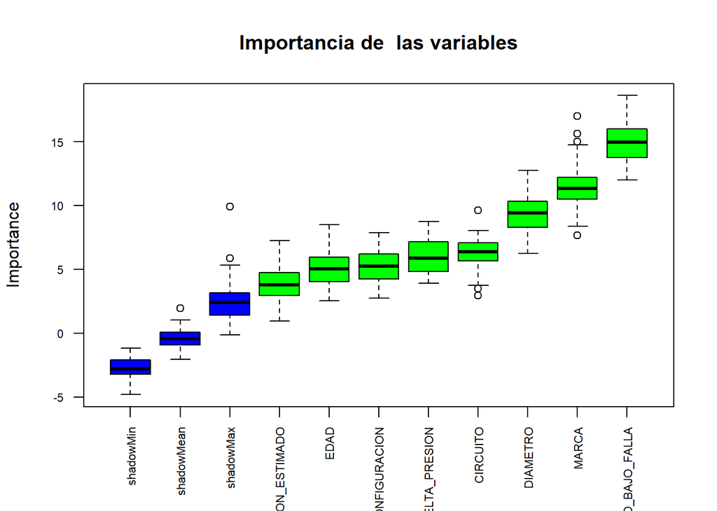

```r
plot(boruta_output, cex.axis=.7, las=2, xlab="", main="Importancia de  las variables")
```

En conclusión Boruta, para este caso de las VRP asume que todas las variables que se están teniendo en cuenta son relevantes en cuanto a su influencia en la probabilidad de fallo y por ende ninguna es eliminada.

### 1.4. RFE (*Recursive Feature Selection*):

Para aplicar RFE, primero se deben de dividir en variables descriptoras (independientes) y variable objetivo (dependiente).

```r
x <- datos[,2:9] #las variables de la 2 a la 9 son descriptoras
y <- datos[,1] #La variable 1 es la variable de interes: FALLA
y<- as.factor(y) #Se configura la clase de FALLA como factor (categórica)
```

Después se configura el algoritmo de la siguiente manera:

1. Se define un control en donde se especifican los detalles de los algoritmos de selección de características, en este caso **functions = rfFuncs** significa que el modelo a ajustar es random forest.

```r
control <- rfeControl(functions=rfFuncs, method="cv", number=10)
```

2. Se ejecuta el algoritmo RFE, dando como parametros a: **x** (variables descriptoras), **y** (variable objetivo), **sizes** significa que se van a analizar subconjuntos de 1 sola variable, luego 2 variables, asi sucesivamente hasta analizar todas las variables juntas.

```r
set.seed(1)
results <- rfe(x,y, sizes=c(1:9), rfeControl=control)
results
```

```
##
## Recursive feature selection
##
## Outer resampling method: Cross-Validated (10 fold)
##
## Resampling performance over subset size:
##
##  Variables Accuracy     Kappa AccuracySD KappaSD Selected
##          1   0.5795 -0.004965    0.05175 0.07720
##          2   0.6175  0.046315    0.03941 0.10197
##          3   0.6296  0.119084    0.05190 0.11293
##          4   0.6364  0.160795    0.05565 0.13969
##          5   0.6771  0.240179    0.04064 0.09803
##          6   0.6677  0.215302    0.04448 0.10329
##          7   0.6704  0.218540    0.04933 0.10523
##          8   0.6826  0.250827    0.04204 0.08881        *
##
## The top 5 variables (out of 8):
##    PRESION_PTO_BAJO_FALLA, MARCA, DIAMETRO, EDAD, CIRCUITO
```

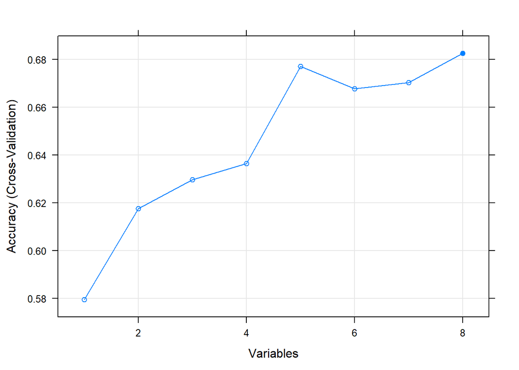

```r
plot(results, type=c("g", "o"))# ver nUmero óptimo de variables con las que el modelo obtiene su mejor efectividad (accuracy)
```

```r
predictors(results)# lista de las variables elegidas, en orden de importancia
```

```
## [1] "PRESION_PTO_BAJO_FALLA"     "MARCA"
## [3] "DIAMETRO"                   "EDAD"
## [5] "CIRCUITO"                   "CONFIGURACION"
## [7] "DELTA_PRESION"              "INDICE_CAVITACION_ESTIMADO"
```

Se logra observar que el algoritmo logra el mejor accuracy con todas las variables predictoras (8 de 8) y según su orden de importancia se tiene que la variable más importante según RFE es presión de punto bajo.

La idea para hacer la eliminación de variables que no aportan al modelo es que una misma variable no sea tenida en cuenta ni por Boruta ni por RFE o de lo contrario que si en uno de los algoritmos, ya sea Boruta o RFE la variable es eliminada en el otro sean de las menos importantes.

## 2. Porcentajes de contribución (%)

El primer paso para generar las medidas de importancia consiste en optimizar el hiperparámetro **mtry** que representa el nivel de profundidad óptimo de los áboles de decisión generados en el modelo **Random forest**.

```r
#Optimizar el hiperparámetro de mtry: Nivel de profundidad
set.seed(1)
bestmtry <- tuneRF(x, y, stepFactor=1.5, improve=1e-5)
```

```
## mtry = 2  OOB error = 33.11%
## Searching left ...
## Searching right ...
## mtry = 3     OOB error = 31.07%
## 0.06147541 1e-05
## mtry = 4     OOB error = 34.74%
## -0.1179039 1e-05
```

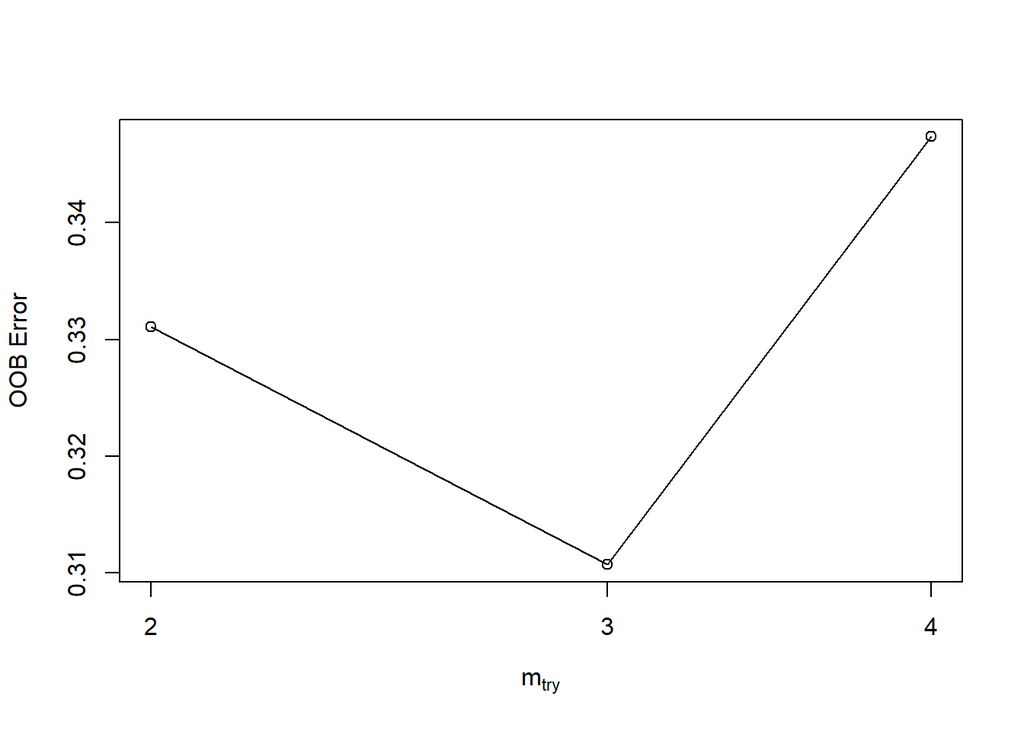

Una vez que ya se conoce que el número óptimo *mtry** es 3, se ajusta al modelo de random forest que se va a generar.

```r
#Ejecutar el modelo con el valor de mtry que se generO en el paso anterior
modelo_randforest <- randomForest(formula = FALLA ~ . ,
                                  data = datos,
                                  mtry = 3,
                                  importance = TRUE,
                                  ntree = 1000)
```

```r
#Evaluar efectividad del modelo
conf <- modelo_randforest$confusion
accuracy_Test <- sum(diag(conf)) / sum(conf)
accuracy_Test
```

```
## [1] 0.6750125
```

```r
importancia <- as.data.frame(modelo_randforest$importance)
importancia <- rownames_to_column(importancia,var = "variable")
gini_pesos <- data.frame(importancia[,1],importancia[,5])
names(gini_pesos)<- c("Variable","Gini")
gini_pesos["Importancia (%) gini"]<- (gini_pesos$Gini/sum(gini_pesos$Gini))*100
gini_pesos <- arrange(gini_pesos, -gini_pesos$`Importancia (%)`)
gini_pesos
```

```
##                     Variable      Gini Importancia (%) gini
## 1     PRESION_PTO_BAJO_FALLA 67.512519            19.917006
## 2                       EDAD 61.020038            18.001646
## 3 INDICE_CAVITACION_ESTIMADO 55.955378            16.507510
## 4                   CIRCUITO 49.834267            14.701709
## 5              DELTA_PRESION 49.710717            14.665260
## 6                      MARCA 26.823466             7.913246
## 7                   DIAMETRO 22.943480             6.768603
## 8              CONFIGURACION  5.169349             1.525020
```

[interactive chart not shown]

Al final se puede tener un último filtro donde aquellas variables cuyo porcentaje de contribución sea inferior a un 5% podrían ser eliminadas, en este caso la variable candidata a eliminar es **configuración**.

```r
datos$CONFIGURACION<-NULL
```

## Porcentajes de contribución final para las VRP

```r
gini_pesos
```

[output not shown]

[interactive chart not shown]